# Chapter 12 Problem 2

Bri Bentley

Mar 27, 2018

**A metallurgic company is investigating lost revenue due to worker illness. It is interested in creating a table of lost revenue to be used for future budgets and company forecasting plans. The data are stored in the data frame** `LOSTR`.

```r
library(PASWR2)
summary(LOSTR)
```

```
##    numbersick     lostrevenue
##  Min.   : 1.00   Min.   : 301
##  1st Qu.: 8.00   1st Qu.:1042
##  Median :14.00   Median :1641
##  Mean   :13.92   Mean   :1644
##  3rd Qu.:19.00   3rd Qu.:2130
##  Max.   :28.00   Max.   :3044
```

```r
head(LOSTR)
```

```
##   numbersick lostrevenue
## 1         19     2107.76
## 2          7      954.93
## 3         14     1589.81
## 4         11     2500.00
## 5         21     2314.64
## 6          9     1062.34
```

1. Create a scatterplot of lost revenue versus number of ill workers. Characterize the relationship between `lostrevenue` and `numbersick`.

There is a postive correlation between `lostrevenue` and `numbersick`. There also appears that there may be a single outlier.

2. Fit a regression line to the data. Superimpose the resulting line in the plot created in part (a).

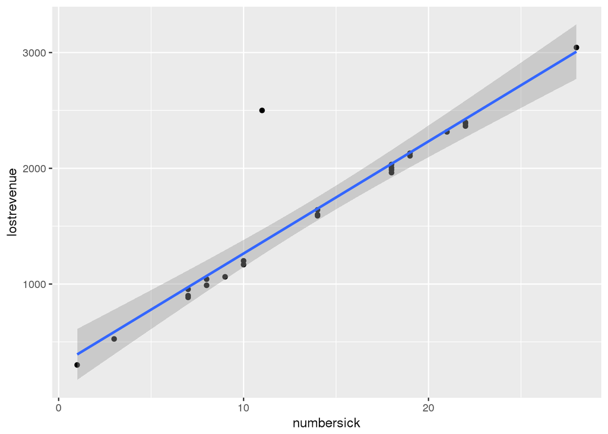

```r
library(ggplot2)
ggplot(data = LOSTR, aes(y = lostrevenue, x = numbersick)) +
  geom_point() +
  geom_smooth(method = "lm")
```

3. Compute the covariance matrix of the B-hats.

```r
mod <- lm(lostrevenue ~ numbersick, data = LOSTR)
X <- model.matrix(mod)
dim(X)
```

```
## [1] 25  2
```

```r
vcov(mod)
```

```
##             (Intercept) numbersick
## (Intercept)  12724.0361 -741.70261
## numbersick    -741.7026   53.28323
```

4. Create a 95% confidence interval for B1.

```r
CI <- confint(mod, level = 0.95)
CI
```

```
##                2.5 %   97.5 %
## (Intercept) 61.49279 528.1855
## numbersick  81.79671 111.9972
```

The confidence interval is $[81.7967148, 111.9971983]$.

5. Compute the coefficient of determination and the adjusted coefficient of determination. Provide contextualual interpretations of both values.

```r
summary(mod)$r.squared
```

```
## [1] 0.8845437
```

```r
summary(mod)$adj.r.squared
```

```
## [1] 0.8795239
```

The coefficient of determination is 0.8845 and the adjusted coefficient of determination is 0.8795.

The coefficient of determination and adjusted coefficient of determination means that about 88.5% and 88%, respectively, of the variance in revenue lost can be explained by the change in `numbersick`.

6. What assumptions need to be satisfied in order to use the model from part (b) for inferential purposes? If there is/are any outlier/s in the data, remove it/them prior to answering the remainder of the questions.

We assume that the errors are assumed to be independent, follow a normal distribution with a mean of zero, and have constant variance.

There is an outlier, data point 4: $(11, 2500)$

```r
library(car)
outlierTest(mod)
```

```
##   rstudent unadjusted p-value Bonferonni p
## 4 42.11082         1.5825e-22   3.9562e-21
```

```r
#Removing the outlier
library(dplyr)
library(tidyverse)
newdata <- LOSTR %>% slice(-4)
newdata
```

```
## # A tibble: 24 x 2
##    numbersick lostrevenue
##         <int>       <dbl>
##  1         19       2108.
##  2          7        955.
##  3         14       1590.
##  4         21       2315.
##  5          9       1062.
##  6         10       1201.
##  7         18       2033.
##  8         22       2396.
##  9         10       1168.
## 10          3        526.
## # ... with 14 more rows
```

7. Determine the expected lost revenues when 5, 15, and 25 workers are absent due to illness.

```r
mod2 <- lm(lostrevenue ~ numbersick, data = newdata)
summary(mod2)
```

```
##
## Call:
## lm(formula = lostrevenue ~ numbersick, data = newdata)
##
## Residuals:
##     Min      1Q  Median      3Q     Max
## -41.459 -16.138  -3.515  23.017  51.129
##
## Coefficients:
##             Estimate Std. Error t value Pr(>|t|)
## (Intercept) 203.8044    12.9492   15.74 1.86e-13 ***
## numbersick   99.9994     0.8295  120.56  < 2e-16 ***
## ---
## Signif. codes:  0 '***' 0.001 '**' 0.01 '*' 0.05 '.' 0.1 ' ' 1
##
## Residual standard error: 27.72 on 22 degrees of freedom
## Multiple R-squared:  0.9985, Adjusted R-squared:  0.9984
## F-statistic: 1.453e+04 on 1 and 22 DF,  p-value: < 2.2e-16
```

```r
ycep <- summary(mod2)$coefficients[1,1]
slope <- summary(mod2)$coefficients[2,1]
ycep
```

```
## [1] 203.8044
```

```r
slope
```

```
## [1] 99.99945
```

```r
ExpLostRev <- slope * c(5, 15, 25) + ycep
ExpLostRev
```

```
## [1]  703.8017 1703.7961 2703.7906
```

The expected lost revenues when 5, 15, and 25 workers are absent due to illness is 703.8016585, 1703.7961376, 2703.7906166 respectively.

8. Compute a 95% prediction interval of lost revenues when 14 workers are absent due to illness.

```r
PI <- predict(mod2, data.frame(numbersick = 14), interval = "predict")
PI
```

```
##        fit      lwr      upr
## 1 1603.797 1545.119 1662.474
```

The 95% prediction interval of lost revenue when 14 workers are absent due to illness is between $(1545.1189599, 1662.4744194)$